# Women's Powerlifting: Best Deadlifts from 1975 to 2019

# Time Series Forecast Using Statistical Approach

**Dataset Rationale:** I chose to stick with my assignment 1 dataset of powerlifting winning weights but use this as an opportunity to explore part of the data that I couldn't include before, which is targeting the individual lifts (bench, deadlift, and squat). I'm going to target deadlifting monthly winning lifts for this time series modeling.

## 1. Data Preparation and Exploration

```python
#Libraries
import matplotlib.pyplot as plt
import numpy as np
import pandas as pd
from statsmodels.graphics.tsaplots import plot_acf
from statsmodels.stats.diagnostic import acorr_ljungbox
from sklearn.ensemble import IsolationForest
from statsmodels.tsa.stattools import adfuller
from statsmodels.tsa.stattools import pacf
from statsmodels.graphics.tsaplots import plot_pacf
from statsmodels.tsa.seasonal import seasonal_decompose
from statsmodels.tsa.statespace.sarimax import SARIMAX
from sklearn.metrics import mean_absolute_percentage_error
```

```python
#Data Importation
#Dataset downloaded from Kaggle at https://www.kaggle.com/datasets/open-powerlifting/powerlifting-database?resource=download
df = pd.read_csv('/Users/alexbevan/Desktop/Dataset Archive/openpowerlifting.csv')

#Filter for women
df = df[df['Sex'] == 'F'] #Filter for women only

#Make a copy
raw_df = df.copy()
```

```python
#Isolating the Deadlift and Inspecting It
df_Deadlift = df[['Deadlift1Kg', 'Deadlift2Kg', 'Deadlift3Kg','Deadlift4Kg', 'Best3DeadliftKg']]
df_Deadlift
```

|  | Deadlift1Kg | Deadlift2Kg | Deadlift3Kg | Deadlift4Kg | Best3DeadliftKg |
| --- | --- | --- | --- | --- | --- |
| 0 | 110.0 | 120.0 | 130.0 | NaN | 130.0 |
| 1 | 130.0 | 140.0 | 145.0 | NaN | 145.0 |
| 2 | NaN | NaN | NaN | NaN | NaN |
| 3 | 132.5 | -140.0 | -140.0 | NaN | 132.5 |
| 4 | 150.0 | 160.0 | 170.0 | NaN | 170.0 |
| ... | ... | ... | ... | ... | ... |
| 1423244 | 95.0 | 105.0 | 107.5 | NaN | 107.5 |
| 1423245 | 80.0 | 90.0 | 102.5 | NaN | 102.5 |
| 1423246 | -120.0 | -120.0 | -120.0 | NaN | NaN |
| 1423247 | 120.0 | 135.0 | 142.5 | NaN | 142.5 |
| 1423248 | 75.0 | 82.5 | 90.0 | NaN | 90.0 |

363165 rows × 5 columns

```python
df.columns
```

```
Index(['Name', 'Sex', 'Event', 'Equipment', 'Age', 'AgeClass', 'Division',
       'BodyweightKg', 'WeightClassKg', 'Squat1Kg', 'Squat2Kg', 'Squat3Kg',
       'Squat4Kg', 'Best3SquatKg', 'Bench1Kg', 'Bench2Kg', 'Bench3Kg',
       'Bench4Kg', 'Best3BenchKg', 'Deadlift1Kg', 'Deadlift2Kg', 'Deadlift3Kg',
       'Deadlift4Kg', 'Best3DeadliftKg', 'TotalKg', 'Place', 'Wilks',
       'McCulloch', 'Glossbrenner', 'IPFPoints', 'Tested', 'Country',
       'Federation', 'Date', 'MeetCountry', 'MeetState', 'MeetName'],
      dtype='object')
```

```python
#Create a Limited Dataframe that Includes Timestamp(s), Best Deadlift and Exogenous Variable

# Convert Date to datetime and drop bad dates
df["Date"] = pd.to_datetime(df["Date"], errors="coerce")
df = df.dropna(subset=["Date"])

# Create Month Index for Model + YearMonth for Legibility
df["Month"] = df["Date"].dt.to_period("M").dt.to_timestamp(how='start')
df["YearMonth"] = df["Date"].dt.to_period("M")

# Keep only rows with a real deadlift value
df = df.dropna(subset=["Best3DeadliftKg","BodyweightKg"])


# Aggregate to one row per month based on max deadlift
idx = df.groupby("Month")["Best3DeadliftKg"].idxmax()

df_monthly = (
    df.loc[idx, ["Month", "Best3DeadliftKg", "BodyweightKg"]]
      .set_index("Month")
      .sort_index()
      .asfreq("MS")   # create missing months
)

# Add YearMonth label back (legible)
df_monthly["YearMonth"] = df_monthly.index.to_period("M")

df_monthly_og = df_monthly.copy()
```

```python
#Missing months examination
missing = df_monthly_og.asfreq("MS").isna().sum()
print("missing before imputation:", missing)
```

```
missing before imputation: Best3DeadliftKg    60
BodyweightKg       60
YearMonth           0
dtype: int64
```

I'm going to be a bit bold and impute. They are also only in the early parts of the historical data. This makes sense because women's powerlifting competitions were few and far between in the 1970s and 80s. I think the best imputation method is to insert data based on values close in time. The only issue I foresee is that the plots for the 1970s and 80s might be suspiciously noiseless.

```python
# Impute missing months
df_monthly_og["Best3DeadliftKg"] = df_monthly_og["Best3DeadliftKg"].interpolate(method="time")
df_monthly_og["BodyweightKg"] = df_monthly_og["BodyweightKg"].interpolate(method="time")
missing = df_monthly_og.asfreq("MS").isna().sum()
print("missing after imputation:", missing)
```

```
missing after imputation: Best3DeadliftKg    0
BodyweightKg       0
YearMonth          0
dtype: int64
```

```python
#Make necesssary feature for outlier model
df_monthly_og["Year"] = df_monthly_og.index.year

#Check for NAs and missing months
print('remaining NAs:', df_monthly_og.isna().sum())

#Check for dtypes
df_monthly_og.info()
```

```
remaining NAs: Best3DeadliftKg    0
BodyweightKg       0
YearMonth          0
Year               0
dtype: int64
<class 'pandas.core.frame.DataFrame'>
DatetimeIndex: 524 entries, 1975-09-01 to 2019-04-01
Freq: MS
Data columns (total 4 columns):
 #   Column           Non-Null Count  Dtype
---  ------           --------------  -----
 0   Best3DeadliftKg  524 non-null    float64
 1   BodyweightKg     524 non-null    float64
 2   YearMonth        524 non-null    period[M]
 3   Year             524 non-null    int32
dtypes: float64(2), int32(1), period[M](1)
memory usage: 18.4 KB
```

```python
#Rename Target Column and DF
df = df_monthly_og.copy()
df = df.rename(columns={'Best3DeadliftKg':'Deadlift'})
```

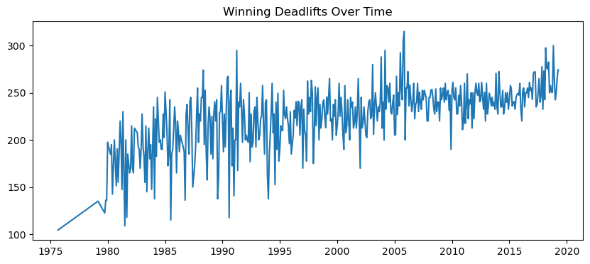

```python
#Initial Plot
plt.figure(figsize=(10, 4))
plt.plot(df["Deadlift"])
plt.title("Winning Deadlifts Over Time")
plt.show()
```

```python
#Inspection
df.head()
```

| Month | Deadlift | BodyweightKg | YearMonth | Year |
| --- | --- | --- | --- | --- |
| 1975-09-01 | 104.330000 | 60.000000 | 1975-09 | 1975 |
| 1975-10-01 | 105.050517 | 60.152702 | 1975-10 | 1975 |
| 1975-11-01 | 105.795051 | 60.310493 | 1975-11 | 1975 |
| 1975-12-01 | 106.515568 | 60.463195 | 1975-12 | 1975 |
| 1976-01-01 | 107.260102 | 60.620987 | 1976-01 | 1976 |

This shows a pretty clear upward trend over the years that is noisy and shows possible heteroskedascity. It shows the expected straight noiseless line in the 1970s.

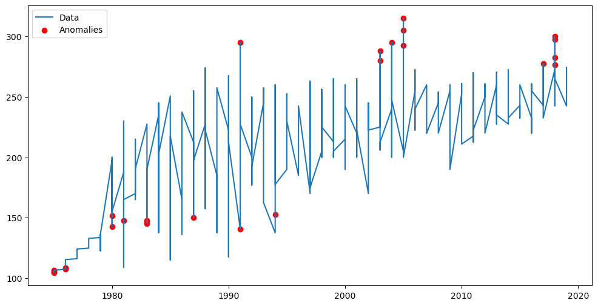

```
Number of anomalies detected: 27
```

```python
#Outlier Detection

#Train Isolation Forest
iso_forest = IsolationForest(contamination=0.05, random_state=42)
df['anomaly_score'] = iso_forest.fit_predict(df[['Deadlift']])

# Plot results
plt.figure(figsize=(12, 6))
plt.plot(df['Year'], df['Deadlift'], label='Data')
plt.scatter(df['Year'][df['anomaly_score'] == -1], df['Deadlift'][df['anomaly_score'] == -1], color='red', label='Anomalies')
plt.legend()
plt.show()

n_anomalies = (df['anomaly_score'] == -1).sum()
print("Number of anomalies detected:", n_anomalies)
```

I think the highs and the lows around 1990 is probably due to the advent of drug testing. The cluster around the mid 2000s is interesting. It would seem that it's entirely due to the entrance of Becca Swanson and her out performing everyone. I'm choosing to leave these in because they do tell part of the story.

```
ADF Test: Deadlift Max
  ADF stat: -2.9595
  p-value : 0.0389
  crit 1%: -3.4433
  crit 5%: -2.8673
  crit 10%: -2.5698
```

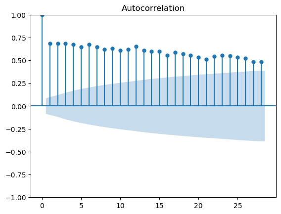

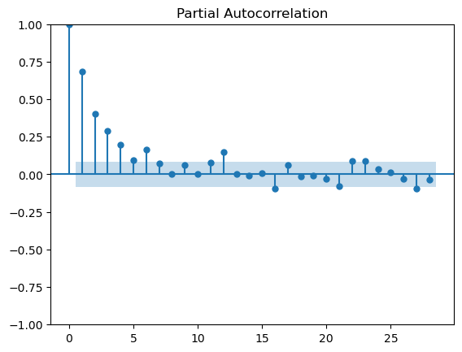

```python
#Stationarity Check and ACF PACF Plots for Hyperparameter Direction

def adf_test(series, name="series"):
    series = series.dropna()
    result = adfuller(series, autolag="AIC")
    print(f"\nADF Test: {name}")
    print(f"  ADF stat: {result[0]:.4f}")
    print(f"  p-value : {result[1]:.4f}")
    for k, v in result[4].items():
        print(f"  crit {k}: {v:.4f}")

adf_test(df["Deadlift"], "Deadlift Max")

plt.figure()
plot_acf(df["Deadlift"].dropna()) #I need to set the lags
plt.show()

plt.figure()
plot_pacf(df["Deadlift"].dropna(), method="ywm")
plt.show()
```

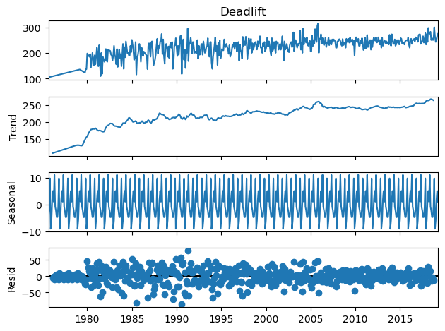

```python
# Seasonal decomposition
if len(df) >= 24:
    decomp = seasonal_decompose(df['Deadlift'], model="additive", period=12)
    decomp.plot()
    plt.show()
```

This shows a clear upward trend and seasonality but highly noisy, albeit the scale is dramatically smaller. The residuals do not appear to hold any pattern but may be heteroskedastic.

## 3. Model Run and Evaluation

```python
#Train/Test: 20% of data

train_size = int(len(df) * 0.8)

train = df.iloc[:train_size]
test  = df.iloc[train_size:]

y_train = train["Deadlift"]
y_test  = test["Deadlift"]

exog_train = train[["BodyweightKg"]]
exog_test  = test[["BodyweightKg"]]

print(y_train.shape)
print(y_test.shape)
print(exog_train.shape)
print(exog_test.shape)
```

```
(419,)
(105,)
(419, 1)
(105, 1)
```

```python
# SARIMA: Seasonal, No Exog (1, 1, 1) (0, 0, 0, 12)

sarima_order = (1, 1, 1)
sarima_seasonal = (0, 0, 0, 12)

sarima_model = SARIMAX(
    y_train,
    order=sarima_order,
    seasonal_order=sarima_seasonal,
    enforce_stationarity=False,
    enforce_invertibility=False
)
sarima_res = sarima_model.fit(disp=False)

print("\nSARIMA summary:")
print(sarima_res.summary())
```

```
SARIMA summary:
                               SARIMAX Results
==============================================================================
Dep. Variable:               Deadlift   No. Observations:                  419
Model:               SARIMAX(1, 1, 1)   Log Likelihood               -1959.691
Date:                Wed, 04 Feb 2026   AIC                           3925.382
Time:                        11:48:14   BIC                           3937.474
Sample:                    09-01-1975   HQIC                          3930.163
                         - 07-01-2010
Covariance Type:                  opg
==============================================================================
                 coef    std err          z      P>|z|      [0.025      0.975]
------------------------------------------------------------------------------
ar.L1         -0.0414      0.047     -0.879      0.379      -0.134       0.051
ma.L1         -0.8890      0.022    -40.686      0.000      -0.932      -0.846
sigma2       721.5156     41.254     17.489      0.000     640.658     802.373
===================================================================================
Ljung-Box (L1) (Q):                   0.08   Jarque-Bera (JB):                40.88
Prob(Q):                              0.78   Prob(JB):                         0.00
Heteroskedasticity (H):               0.66   Skew:                            -0.40
Prob(H) (two-sided):                  0.01   Kurtosis:                         4.31
===================================================================================

Warnings:
[1] Covariance matrix calculated using the outer product of gradients (complex-step).
```

**Observations**

- AR is insignificant
- MA is significant, so the future lifts are stronlgy dictated by the shocks of yesterday
- The noise is also significant.
- The model seems to have removed the trend from the Ljung Box score which is tiny.
- The AIC and BIC are high.
- There are heavy tails in the kurtosis (but I knew that this would be outlier heavy)
- There is a moderate left skew which also makes sense since women lift heavier as time goes on
- The model confirms heterskedasticity so we may have to stabilize the variance

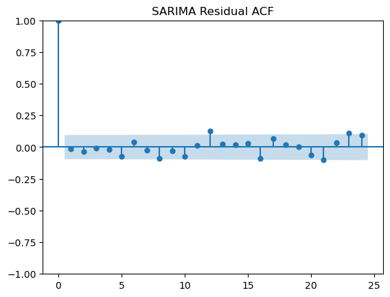

```
Ljung–Box test:       lb_stat  lb_pvalue
12  17.034517   0.148303
```

```python
#Plotting the Residuals

def residual_diagnostics(residuals, lags=24):
    residuals = residuals.dropna()

    # ACF plot
    plt.figure()
    plot_acf(residuals, lags=lags)
    plt.title("SARIMA Residual ACF")
    plt.show()

    # Ljung–Box Test Detecting Trend in the Residuals
    lb = acorr_ljungbox(residuals, lags=[lags//2], return_df=True)
    print("Ljung–Box test:", lb)

residual_diagnostics(sarima_res.resid)
```

**Observations:** The residuals are looking very good and undercontrol. There is no autocorrelation here. There might be one poking its head up at lag 12 which means there is still some seasonal element that is not captured in the model

```python
#Extracting the MAPE

#Predict Values Based on the Model
forecast_steps = len(y_test)
fc = sarima_res.get_forecast(steps=forecast_steps)
y_pred1 = fc.predicted_mean

mape = mean_absolute_percentage_error(y_test, y_pred1)
print(f"MAPE: {mape:.2%}")
```

```
MAPE: 5.39%
```

**Observations:** This is looking very very good. We are only off by 5% from the true values.

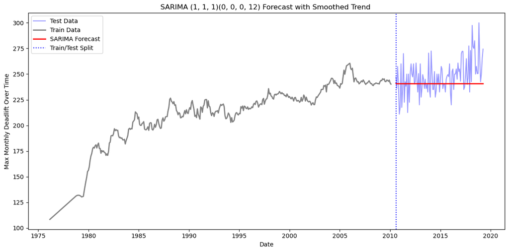

```python
#Extracting a Forecast

plt.figure(figsize=(12, 6))

# Actual values
plt.plot(y_test.index, y_test,
         color="blue", alpha=0.4, label="Test Data")

# Smoothed trend
y_smooth = y_train.rolling(window=12, center=True).mean()

plt.plot(y_smooth.index, y_smooth,
         color="gray", linewidth=2, label="Train Data")

# Predictions
plt.plot(y_pred1.index, y_pred1,
         color="red", linewidth=2, label="SARIMA Forecast")

# Train/Test split line
plt.axvline(y_test.index[0], color="blue", linestyle=":", label="Train/Test Split")

plt.title("SARIMA (1, 1, 1)(0, 0, 0, 12) Forecast with Smoothed Trend ")
plt.xlabel("Date")
plt.ylabel("Max Monthly Deadlift Over Time")
plt.legend()
plt.tight_layout()
plt.show()
```

**Observations:** This is slightly disappointing after seeing that MAPE score. The strengths of the forecast are that is farily accurate and conservative as an esimtate of where deadlifting is going. We see a small leveling off starting around 2005. This makes me think that perhaps there's a limit to what the body can take in these endeavours.

## 4. Adjustments: Treating Any Coefficient Stability, Skew, Variance, Expontential Growth

Options:

- Adjust hyperparameters: For such a noisy series initially, I'm really happy with the first model and where it stands. I think I could possibly add in seasonal AR differencing.
- Feature engineering: One thing I did think of is make a new variable which is the ratio of deadlift to bodyweight. Would this perhaps stabilize noise and capture a more accurate forecast? So I would embedding the exog variable in as part of a new target. But before I do that, let's add it as an exog var in the model so see if this has any traction.

## 5. Exogenous Variable Analysis

```python
# SARIMA: Seasonal AR Differencing and Exog (1, 1, 1,)(1, 0, 0, 12)

sarimax_order = (1, 1, 1)
sarimax_seasonal = (1, 0, 0, 12)

sarimax_model = SARIMAX(
    y_train,
    exog=exog_train,
    order=sarimax_order,
    seasonal_order=sarimax_seasonal,
    enforce_stationarity=False,
    enforce_invertibility=False
)
sarimax_res2 = sarimax_model.fit(disp=False)

print("\nSARIMAX summary:")
print(sarimax_res2.summary())
```

```
SARIMAX summary:
                                      SARIMAX Results
===========================================================================================
Dep. Variable:                            Deadlift   No. Observations:                  419
Model:             SARIMAX(1, 1, 1)x(1, 0, [], 12)   Log Likelihood               -1873.732
Date:                             Wed, 04 Feb 2026   AIC                           3757.465
Time:                                     11:48:14   BIC                           3777.484
Sample:                                 09-01-1975   HQIC                          3765.389
                                      - 07-01-2010
Covariance Type:                               opg
================================================================================
                   coef    std err          z      P>|z|      [0.025      0.975]
--------------------------------------------------------------------------------
BodyweightKg     0.6958      0.070      9.926      0.000       0.558       0.833
ar.L1           -0.0699      0.048     -1.465      0.143      -0.163       0.024
ma.L1           -0.8949      0.024    -37.788      0.000      -0.941      -0.849
ar.S.L12         0.1391      0.039      3.551      0.000       0.062       0.216
sigma2         609.4603     34.486     17.672      0.000     541.868     677.052
===================================================================================
Ljung-Box (L1) (Q):                   0.04   Jarque-Bera (JB):                39.45
Prob(Q):                              0.84   Prob(JB):                         0.00
Heteroskedasticity (H):               0.67   Skew:                            -0.21
Prob(H) (two-sided):                  0.02   Kurtosis:                         4.47
===================================================================================

Warnings:
[1] Covariance matrix calculated using the outer product of gradients (complex-step).
```

**Obserations:** Okay. So bodyweight is a significant variable. The AR trend is removed here and MA remains significant. But now there is a seasonal AR that is making its presence felt. And like before, there is a lot of noise. Heteroskedasticity remains here. So maybe that is the next thing to fix by applying a log to the deadlift.

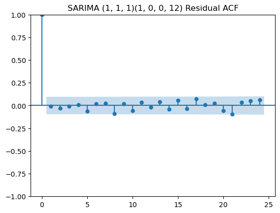

```
Ljung–Box test:      lb_stat  lb_pvalue
12  8.347453   0.757423
```

```python
#Resdidual Diagnostics
def residual_diagnostics(residuals, lags=24):
    residuals = residuals.dropna()

    # ACF plot
    plt.figure()
    plot_acf(residuals, lags=lags)
    plt.title("SARIMA (1, 1, 1)(1, 0, 0, 12) Residual ACF")
    plt.show()

    # Ljung–Box Test Detecting Trend in the Residuals
    lb = acorr_ljungbox(residuals, lags=[lags//2], return_df=True)
    print("Ljung–Box test:", lb)

residual_diagnostics(sarimax_res2.resid)
```

```python
#Extracting the MAPE

#Predict Values Based on the Model
forecast_steps = len(y_test)
fc = sarimax_res2.get_forecast(steps=forecast_steps, exog=exog_test)
y_pred2 = fc.predicted_mean

mape = mean_absolute_percentage_error(y_test, y_pred2)
print(f"MAPE: {mape:.2%}") #Remains small but slightly increased
```

```
MAPE: 7.60%
```

**Observations:** The Mape increased slightly. It seems that adding in the exog variable or the seasonal AR differencing made the model lose some of its predicative accuracy.

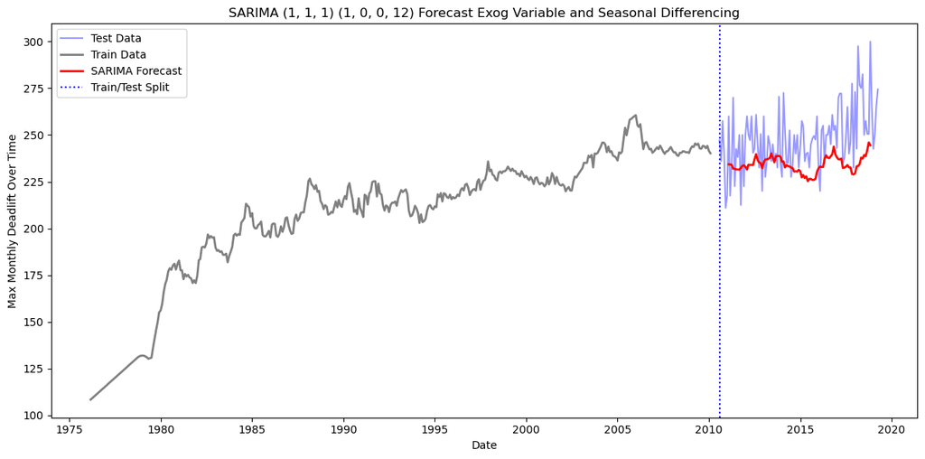

```python
#Forecasting

plt.figure(figsize=(12, 6))

# Actual values
plt.plot(y_test.index, y_test,
         color="blue", alpha=0.4, label="Test Data")

# Smoothed trend
y_smooth = y_train.rolling(window=12, center=True).mean()
y_pred2_smooth = y_pred2.rolling(window=12, center=True).mean()

plt.plot(y_smooth.index, y_smooth,
         color="gray", linewidth=2, label="Train Data")

# Predictions
plt.plot(y_pred2_smooth.index, y_pred2_smooth,
         color="red", linewidth=2, label="SARIMA Forecast")

# Train/Test split line
plt.axvline(y_test.index[0], color="blue", linestyle=":", label="Train/Test Split")

plt.title("SARIMA (1, 1, 1) (1, 0, 0, 12) Forecast Exog Variable and Seasonal Differencing")
plt.xlabel("Date")
plt.ylabel("Max Monthly Deadlift Over Time")
plt.legend()
plt.tight_layout()
plt.show()
```

**Observations:** So this is better. My next steps are:

1. Stabilize variance with log and rerun
2. Remove seasonal AR differencing but keep exog then rerun
3. Reimpute exog using mean rather than time (the imputation method may have generated some dodgy data)

```python
#Log transform train and test

y_train_log = np.log(y_train)
y_test_log = np.log(y_test)
```

```
SARIMAX summary:
                                      SARIMAX Results
===========================================================================================
Dep. Variable:                            Deadlift   No. Observations:                  419
Model:             SARIMAX(1, 1, 1)x(1, 0, [], 12)   Log Likelihood                 263.249
Date:                             Wed, 04 Feb 2026   AIC                           -516.498
Time:                                     11:48:14   BIC                           -496.479
Sample:                                 09-01-1975   HQIC                          -508.574
                                      - 07-01-2010
Covariance Type:                               opg
================================================================================
                   coef    std err          z      P>|z|      [0.025      0.975]
--------------------------------------------------------------------------------
BodyweightKg     0.0034      0.000      9.405      0.000       0.003       0.004
ar.L1           -0.0607      0.048     -1.270      0.204      -0.154       0.033
ma.L1           -0.8764      0.024    -35.909      0.000      -0.924      -0.829
ar.S.L12         0.1355      0.036      3.787      0.000       0.065       0.206
sigma2           0.0159      0.001     20.014      0.000       0.014       0.017
===================================================================================
Ljung-Box (L1) (Q):                   0.01   Jarque-Bera (JB):               166.50
Prob(Q):                              0.93   Prob(JB):                         0.00
Heteroskedasticity (H):               0.39   Skew:                            -0.74
Prob(H) (two-sided):                  0.00   Kurtosis:                         5.77
===================================================================================

Warnings:
[1] Covariance matrix calculated using the outer product of gradients (complex-step).
```

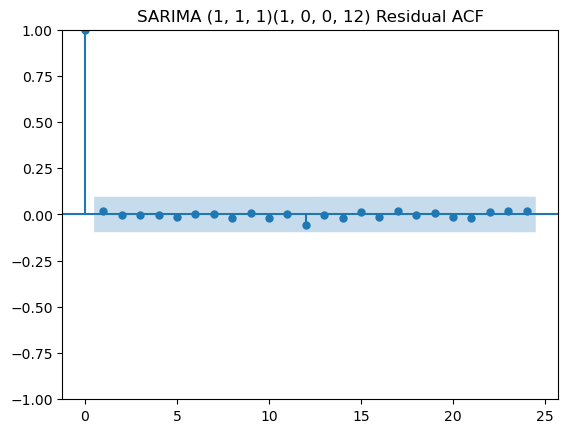

```
Ljung–Box test:      lb_stat  lb_pvalue
12  2.102472   0.999232
```

```python
# SARIMA: Log with Seasonal AR Differencing and Exog (1, 1, 1,)(1, 0, 0, 12)

sarimax_order = (1, 1, 1)
sarimax_seasonal = (1, 0, 0, 12)

sarimax_model = SARIMAX(
    y_train_log,
    exog=exog_train,
    order=sarimax_order,
    seasonal_order=sarimax_seasonal,
    enforce_stationarity=False,
    enforce_invertibility=False
)
sarimax_res3 = sarimax_model.fit(disp=False)

print("\nSARIMAX summary:")
print(sarimax_res3.summary())
residual_diagnostics(sarimax_res3.resid)
```

```python
#Predict Values Based on the Model

forecast_steps = len(y_test)
fc = sarimax_res3.get_forecast(steps=forecast_steps, exog=exog_test)
y_pred3 = fc.predicted_mean

mape = mean_absolute_percentage_error(y_test_log, y_pred3)
print(f"MAPE: {mape:.2%}") #Remains small but slightly increased
```

```
MAPE: 1.62%
```

**Observations:** The MAPE is terrific but the plot looks exactly the same. Let's remove seasonal AR differencing.

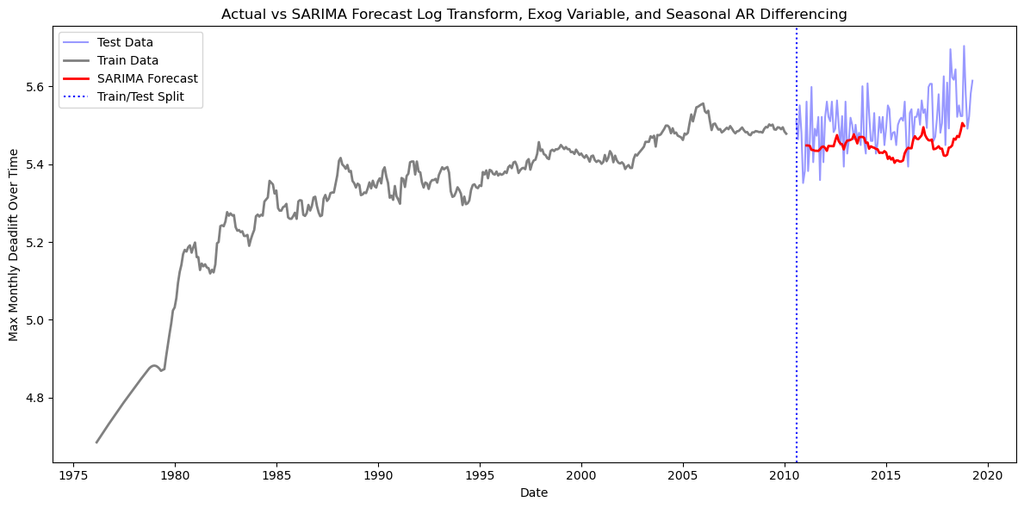

```python
#Forecasting Log Y SARIMA

plt.figure(figsize=(12, 6))

# Actual values
plt.plot(y_test_log.index, y_test_log,
         color="blue", alpha=0.4, label="Test Data")

# Smoothed trend
y_smooth_log = y_train_log.rolling(window=12, center=True).mean()
y_pred3_smooth = y_pred3.rolling(window=12, center=True).mean()

plt.plot(y_smooth_log.index, y_smooth_log,
         color="gray", linewidth=2, label="Train Data")

# Predictions
plt.plot(y_pred3_smooth.index, y_pred3_smooth,
         color="red", linewidth=2, label="SARIMA Forecast")

# Train/Test split line
plt.axvline(y_test_log.index[0], color="blue", linestyle=":", label="Train/Test Split")

plt.title("Actual vs SARIMA Forecast Log Transform, Exog Variable, and Seasonal AR Differencing")
plt.xlabel("Date")
plt.ylabel("Max Monthly Deadlift Over Time")
plt.legend()
plt.tight_layout()
plt.show()
```

```
SARIMAX summary:
                               SARIMAX Results
==============================================================================
Dep. Variable:               Deadlift   No. Observations:                  419
Model:               SARIMAX(1, 1, 1)   Log Likelihood                 271.960
Date:                Wed, 04 Feb 2026   AIC                           -535.921
Time:                        11:48:14   BIC                           -519.798
Sample:                    09-01-1975   HQIC                          -529.546
                         - 07-01-2010
Covariance Type:                  opg
================================================================================
                   coef    std err          z      P>|z|      [0.025      0.975]
--------------------------------------------------------------------------------
BodyweightKg     0.0035      0.000      9.707      0.000       0.003       0.004
ar.L1           -0.0559      0.046     -1.215      0.224      -0.146       0.034
ma.L1           -0.8625      0.026    -33.688      0.000      -0.913      -0.812
sigma2           0.0158      0.001     20.542      0.000       0.014       0.017
===================================================================================
Ljung-Box (L1) (Q):                   0.06   Jarque-Bera (JB):               227.88
Prob(Q):                              0.81   Prob(JB):                         0.00
Heteroskedasticity (H):               0.43   Skew:                            -0.85
Prob(H) (two-sided):                  0.00   Kurtosis:                         6.20
===================================================================================

Warnings:
[1] Covariance matrix calculated using the outer product of gradients (complex-step).
```

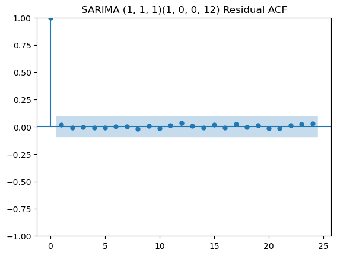

```
Ljung–Box test:     lb_stat  lb_pvalue
12  1.06365    0.99998
```

```python
#SARIMA: Log with Exog (1, 1, 1,)(0, 0, 0, 12)

sarimax_order = (1, 1, 1)
sarimax_seasonal = (0, 0, 0, 12)

sarimax_model = SARIMAX(
    y_train_log,
    exog=exog_train,
    order=sarimax_order,
    seasonal_order=sarimax_seasonal,
    enforce_stationarity=False,
    enforce_invertibility=False
)
sarimax_res4 = sarimax_model.fit(disp=False)

print("\nSARIMAX summary:")
print(sarimax_res4.summary())
residual_diagnostics(sarimax_res4.resid)
```

**Observations:** The skew and heteroskedascticity have worsened. A Box Cox may be necessary in place of a log transformation.

```
MAPE: 1.64%
```

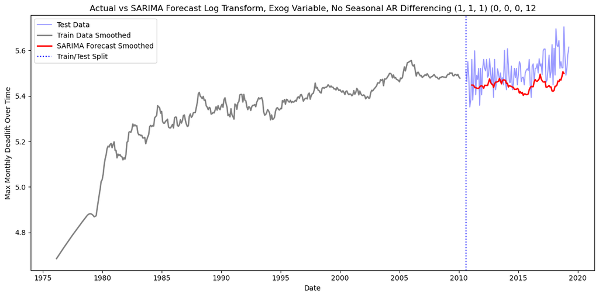

```python
#Forecasting


forecast_steps = len(y_test)
fc = sarimax_res4.get_forecast(steps=forecast_steps, exog=exog_test)
y_pred4 = fc.predicted_mean

mape = mean_absolute_percentage_error(y_test_log, y_pred4)
print(f"MAPE: {mape:.2%}") #Remains small but slightly increased

plt.figure(figsize=(12, 6))

# Actual values
plt.plot(y_test_log.index, y_test_log,
         color="blue", alpha=0.4, label="Test Data")

# Smoothed trend
y_smooth = y_train_log.rolling(window=12, center=True).mean()
y_pred4_smooth = y_pred4.rolling(window=12, center=True).mean()

#y_train data
plt.plot(y_smooth.index, y_smooth,
         color="gray", linewidth=2, label="Train Data Smoothed")

# Predictions
plt.plot(y_pred4_smooth.index, y_pred4_smooth,
         color="red", linewidth=2, label="SARIMA Forecast Smoothed")

# Train/Test split line
plt.axvline(y_test_log.index[0], color="blue", linestyle=":", label="Train/Test Split")

plt.title("Actual vs SARIMA Forecast Log Transform, Exog Variable, No Seasonal AR Differencing (1, 1, 1) (0, 0, 0, 12")
plt.xlabel("Date")
plt.ylabel("Max Monthly Deadlift Over Time")
plt.legend()
plt.tight_layout()
plt.show()
```

```python
# Reimpute Missing Monthls for BodyWeight to be Mean

df_monthly["Best3DeadliftKg"] = df_monthly["Best3DeadliftKg"].interpolate(method="time")
df_monthly["BodyweightKg"] = df_monthly["BodyweightKg"].fillna(df["BodyweightKg"].mean())
df = df_monthly.copy()

#Check for Intactness of the Data: Missing Nans etc
df.isna().sum()
```

```
Best3DeadliftKg    0
BodyweightKg       0
YearMonth          0
dtype: int64
```

```python
#Train/Test: 20% of data
train_size = int(len(df) * 0.8)

train = df.iloc[:train_size]
test  = df.iloc[train_size:]

y_train = train["Best3DeadliftKg"]
y_test  = test["Best3DeadliftKg"]

exog_train = train[["BodyweightKg"]]
exog_test  = test[["BodyweightKg"]]
```

```python
#Apply the log

y_train_log = np.log(y_train)
y_test_log = np.log(y_test)
```

```
SARIMAX summary:
                                      SARIMAX Results
===========================================================================================
Dep. Variable:                     Best3DeadliftKg   No. Observations:                  419
Model:             SARIMAX(1, 1, 1)x(1, 0, [], 12)   Log Likelihood                 259.435
Date:                             Wed, 04 Feb 2026   AIC                           -508.869
Time:                                     11:48:15   BIC                           -488.850
Sample:                                 09-01-1975   HQIC                          -500.945
                                      - 07-01-2010
Covariance Type:                               opg
================================================================================
                   coef    std err          z      P>|z|      [0.025      0.975]
--------------------------------------------------------------------------------
BodyweightKg     0.0033      0.000      8.576      0.000       0.003       0.004
ar.L1           -0.0562      0.048     -1.168      0.243      -0.150       0.038
ma.L1           -0.8621      0.025    -34.311      0.000      -0.911      -0.813
ar.S.L12         0.1378      0.036      3.827      0.000       0.067       0.208
sigma2           0.0162      0.001     20.482      0.000       0.015       0.018
===================================================================================
Ljung-Box (L1) (Q):                   0.02   Jarque-Bera (JB):               164.87
Prob(Q):                              0.88   Prob(JB):                         0.00
Heteroskedasticity (H):               0.37   Skew:                            -0.71
Prob(H) (two-sided):                  0.00   Kurtosis:                         5.78
===================================================================================

Warnings:
[1] Covariance matrix calculated using the outer product of gradients (complex-step).
```

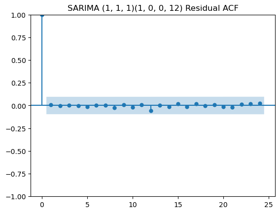

```
Ljung–Box test:      lb_stat  lb_pvalue
12  1.983425   0.999431
```

```python
# SARIMA: Log with Seasonal AR Differencing and Reimputed Exog (1, 1, 1,)(1, 0, 0, 12)



sarimax_order = (1, 1, 1)
sarimax_seasonal = (1, 0, 0, 12)

sarimax_model = SARIMAX(
    y_train_log,
    exog=exog_train,
    order=sarimax_order,
    seasonal_order=sarimax_seasonal,
    enforce_stationarity=False,
    enforce_invertibility=False
)
sarimax_res5 = sarimax_model.fit(disp=False)

print("\nSARIMAX summary:")
print(sarimax_res5.summary())
residual_diagnostics(sarimax_res5.resid)
```

```
MAPE: 1.58%
```

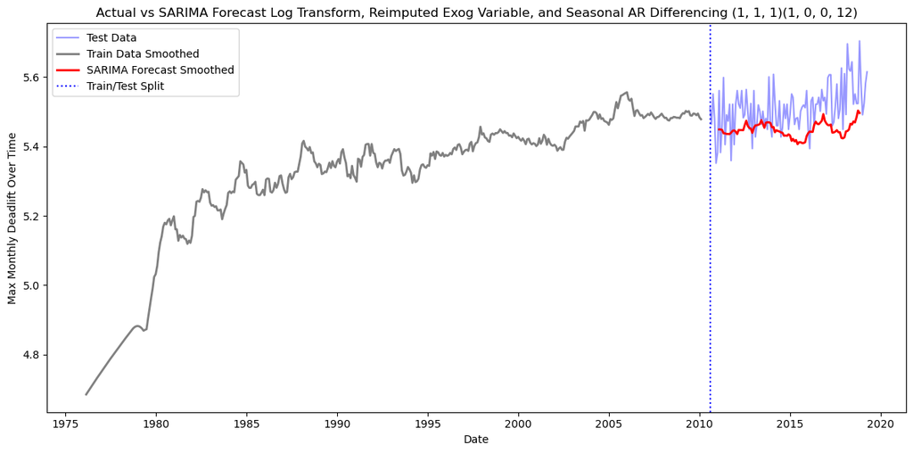

```python
forecast_steps = len(y_test)
fc = sarimax_res5.get_forecast(steps=forecast_steps, exog=exog_test)
y_pred5 = fc.predicted_mean

mape = mean_absolute_percentage_error(y_test_log, y_pred5)
print(f"MAPE: {mape:.2%}") #Remains small but slightly increased

plt.figure(figsize=(12, 6))

# Actual values
plt.plot(y_test_log.index, y_test_log,
         color="blue", alpha=0.4, label="Test Data")

# Smoothed trend
y_smooth = y_train_log.rolling(window=12, center=True).mean()
y_pred5_smooth = y_pred5.rolling(window=12, center=True).mean()

plt.plot(y_smooth.index, y_smooth,
         color="gray", linewidth=2, label="Train Data Smoothed")

# Predictions
plt.plot(y_pred5_smooth.index, y_pred5_smooth,
         color="red", linewidth=2, label="SARIMA Forecast Smoothed")

# Train/Test split line
plt.axvline(y_test_log.index[0], color="blue", linestyle=":", label="Train/Test Split")

plt.title("Actual vs SARIMA Forecast Log Transform, Reimputed Exog Variable, and Seasonal AR Differencing (1, 1, 1)(1, 0, 0, 12)")
plt.xlabel("Date")
plt.ylabel("Max Monthly Deadlift Over Time")
plt.legend()
plt.tight_layout()
plt.show()
```

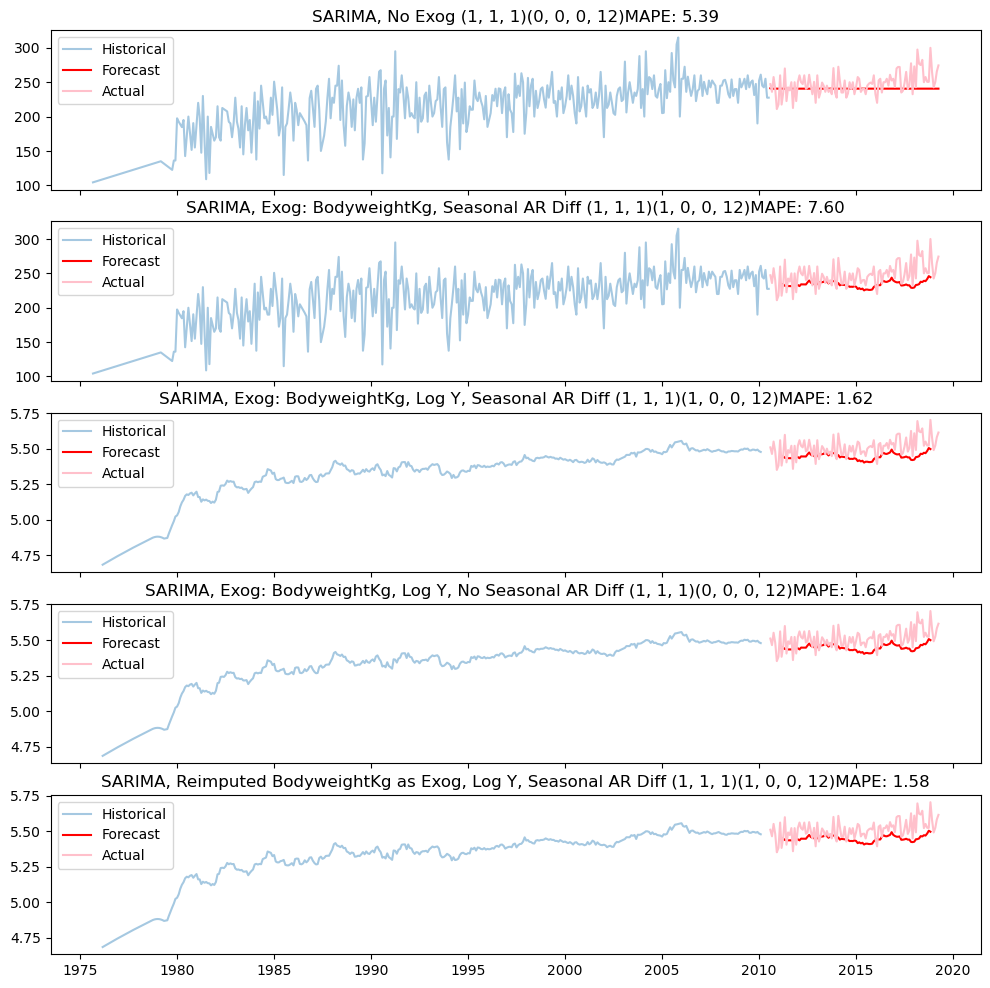

```python
fig, axes = plt.subplots(nrows=5, ncols=1, figsize=(12, 12), sharex=True)

#Plot 1
axes[0].plot(y_train.index, y_train, label="Historical", alpha=0.4)
axes[0].plot(y_pred1.index, y_pred1, color='red', label="Forecast")
axes[0].plot(y_test.index, y_test, color="pink", label="Actual")
axes[0].set_title("SARIMA, No Exog (1, 1, 1)(0, 0, 0, 12)MAPE: 5.39")
axes[0].legend()

axes[1].plot(y_train.index, y_train, label="Historical", alpha=0.4)
axes[1].plot(y_pred2_smooth.index, y_pred2_smooth, color='red', label="Forecast")
axes[1].plot(y_test.index, y_test, color='pink', label="Actual")
axes[1].set_title("SARIMA, Exog: BodyweightKg, Seasonal AR Diff (1, 1, 1)(1, 0, 0, 12)MAPE: 7.60")
axes[1].legend()

axes[2].plot(y_smooth_log.index, y_smooth_log, label="Historical", alpha=0.4)
axes[2].plot(y_pred3_smooth.index, y_pred3_smooth, color='red', label="Forecast")
axes[2].plot(y_test_log.index, y_test_log, color='pink', label="Actual")
axes[2].set_title("SARIMA, Exog: BodyweightKg, Log Y, Seasonal AR Diff (1, 1, 1)(1, 0, 0, 12)MAPE: 1.62")
axes[2].legend()

axes[3].plot(y_smooth_log.index, y_smooth_log, label="Historical", alpha=0.4)
axes[3].plot(y_pred4_smooth.index, y_pred4_smooth, color='red', label="Forecast")
axes[3].plot(y_test_log.index, y_test_log, color='pink', label="Actual")
axes[3].set_title("SARIMA, Exog: BodyweightKg, Log Y, No Seasonal AR Diff (1, 1, 1)(0, 0, 0, 12)MAPE: 1.64")
axes[3].legend()

axes[4].plot(y_smooth_log.index, y_smooth_log, label="Historical", alpha=0.4)
axes[4].plot(y_pred5_smooth.index, y_pred5_smooth, color='red', label="Forecast")
axes[4].plot(y_test_log.index, y_test_log, color='pink', label="Actual")
axes[4].set_title("SARIMA, Reimputed BodyweightKg as Exog, Log Y, Seasonal AR Diff (1, 1, 1)(1, 0, 0, 12)MAPE: 1.58")
axes[4].legend()
```

## 6. Reflection

**Best Model: SARIMA: Reimputed Exog, Log Y, and Seasonal AR Differencing (1, 1, 1) (1, 0, 0, 12) MAPE: 1.58%**

**Was my inital instinct right in terms of the first model?** My instinct about the model was pretty spot on. But I had assignment 1 to work off of so that gave me an advantage. I knew the series would be noisy and seasonal.

**What is the story here that the data is telling me?** I think parsing out one lift from the three that comprise powerlifting competitions revealed a story with further clarity than before. Since 1975, the field has seen a relentless upward trend as nutrition and performance enhancing drugs have impacted the field in addition to a wider acceptance and funding of women's powerlifting. However, I see the upward trend leveling out in the mid 2000s and the forecast also shows a leveling out. One factor might be the limitations of the human body - there is only so much that a person can deadlift without breaking themselves. There is only so much muscle a human frame can support. I also wonder if this leveling may be 1) a redirection in attention to the other two lifts for competitors for some reason or 2) perhaps with the greater acceptance of the sport, we are also seeing somewhat of a declining interest and narrowing of funding sources. It's not sensationalized as "freakish" in quite the same way that it was in the 1980s through 2000s. Does social acceptance result in a bit of complacency?

**What have I learned from this?**

1. Take care when imputing because it is a pain to have to go back and do it again.
2. Perhaps have more of a strategy in treating outliers, however important they may be
3. Treat heteroskedascity when it first appears. Don't put this on the back burner.
4. Any EDA and preemptive feature engineering always pays off. Don't skip this for any reason.
5. Take care to set up a strong notation system when handling plots and models that will last you through the whole project.
6. Time series does well with a bit of trusting your gut and intuition will become stronger with experience.